# A Framework and Application for Efficient Analysis of Peptide Libraries

Eric Riemer Hare  
02-06-2014

### Introduction

Peptide Libraries are important in a number of fields for a number of different applications:

- Protein Interaction
- Vaccine Research
- Drug Screening

### Problems

- Cost - The more peptides (or better encoding schemes), the more expensive
- Quality - The fewer different peptides, the less useful for most applications

Being able to assess the quality of a peptide library, and doing so in a way so as to minimize cost, should help researchers make better choices about which peptide libraries to synthesize and purchase.

### Framework

My project is a three-layer tool to assess the statistical properties of peptide libraries.

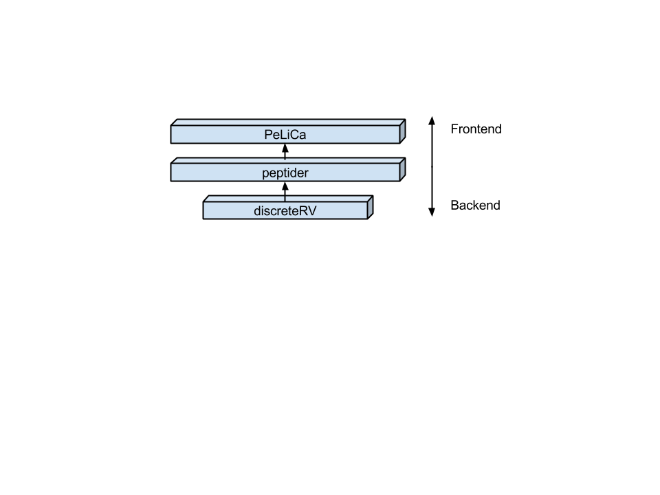

### discreteRV

Manipulation of Discrete Random Variables

- Based on idea and code by Andreas Buja (Wharton School of Business)
- My contribution: additional functionality, packaging, documentation, and write-up

### Installing discreteRV

discreteRV is available on CRAN (stable) and GitHub (development)

(1) Install from CRAN or GitHub

```r
install.packages("discreteRV")
# or...
library(devtools)
install_github("discreteRV", "erichare")
```

(2) Load the package

```r
library(discreteRV)
```

### Creating discrete random variables

Let X be a random variable representing a single toss of a fair die. X takes on the values 1 to 6 with probability \( \frac{1}{6} \)

\( P(X = x) = \frac{1}{6} \ \ \ \ x \in \{1, 2, 3, 4, 5, 6\} \)

In discreteRV,

```r
X <- make.RV(1:6, rep(1/6, 6), fractions = TRUE)
X
```

```
random variable with 6 outcomes

  1   2   3   4   5   6
1/6 1/6 1/6 1/6 1/6 1/6
```

### Creating discrete random variables (continued)

Let Y be distributed according to a poisson random variable with mean parameter 5.

\( P(Y = y) = \frac{\lambda^ye^{-\lambda}}{y!} \ \ \ \ y \in \{0, 1, ...\} \)

```r
lambda <- 5
y <- 0:100

Y <- make.RV(y, (lambda^y * exp(-lambda)) / factorial(y))
```

### Plot Method

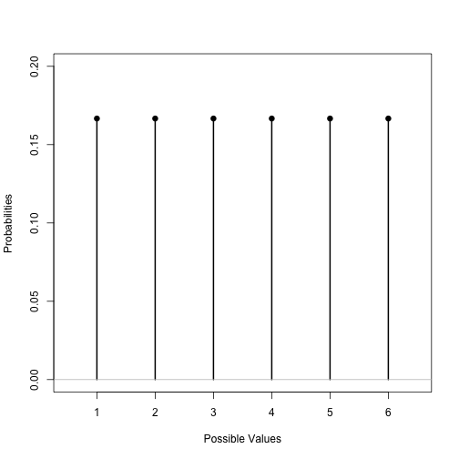

```r
plot(X)
```

### Probability Functions

discreteRV features probability functions which have a syntax very similar to Casella & Berger:

```r
P(X > 3)
```

```
[1] 0.5
```

```r
P(X < 1 | X >= 5)
```

```
[1] 0.3333
```

### Probability Functions (continued)

```r
E(X)
```

```
[1] 3.5
```

```r
V(X)
```

```
[1] 2.917
```

```r
SD(X)
```

```
[1] 1.708
```

### Probability Functions (continued)

```r
E(Y)
```

```
[1] 5
```

```r
V(Y)
```

```
[1] 5
```

```r
SD(Y)
```

```
[1] 2.236
```

### Joint Distributions

discreteRV allows easy computation of joint distributions:

```r
multN(X, n = 2, fractions = TRUE)
```

```
random variable with 36 outcomes

 1.1  1.2  1.3  1.4  1.5  1.6  2.1  2.2  2.3  2.4  2.5  2.6  3.1  3.2  3.3
1/36 1/36 1/36 1/36 1/36 1/36 1/36 1/36 1/36 1/36 1/36 1/36 1/36 1/36 1/36
 3.4  3.5  3.6  4.1  4.2  4.3  4.4  4.5  4.6  5.1  5.2  5.3  5.4  5.5  5.6
1/36 1/36 1/36 1/36 1/36 1/36 1/36 1/36 1/36 1/36 1/36 1/36 1/36 1/36 1/36
 6.1  6.2  6.3  6.4  6.5  6.6
1/36 1/36 1/36 1/36 1/36 1/36
```

### Sum of Random Variables

We can obtain a new random variable by summing independent realizations of a random variable:

```r
SofIID(X, n = 2, fractions = TRUE)
```

```
random variable with 11 outcomes

   2    3    4    5    6    7    8    9   10   11   12
1/36 1/18 1/12  1/9 5/36  1/6 5/36  1/9 1/12 1/18 1/36
```

### Simulations

We can simulate trials from any defined random variable:

```r
X.sim <- rsim(10, X)
X.sim
```

```
1/6 1/6 1/6 1/6 1/6 1/6 1/6 1/6 1/6 1/6
  1   2   6   3   4   2   2   6   6   3
attr(,"RV")
random variable with 6 outcomes

  1   2   3   4   5   6
1/6 1/6 1/6 1/6 1/6 1/6
attr(,"class")
[1] "RVsim"
```

### Simulations (continued)

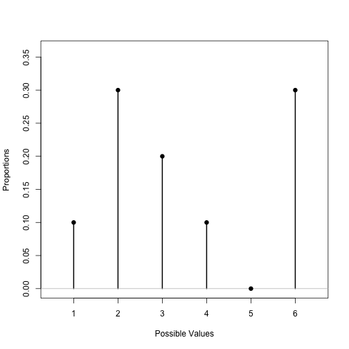

```r
plot(X.sim)
```

### An Application of discreteRV

Peptides are chains of amino acids linked by peptide bonds

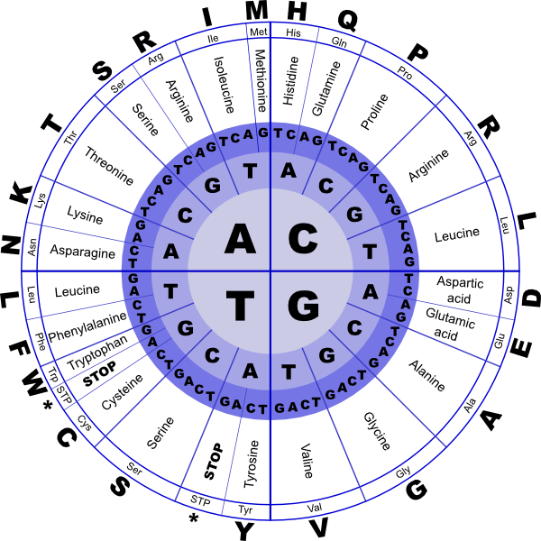

Suppose we regard each amino acid as independent of the others in a peptide…

### peptider

peptider is an R package, built on top of discreteRV, which allows for the statistical analysis of peptide libraries.

- Written by Dr. Hofmann and I, based on the work of Sieber et. al

### Installing Peptder

(1) Install from CRAN or GitHub

```r
install.packages("peptider")
# or...
library(devtools)
install_github("peptider", "heike")
```

(2) Load the package

```r
library(peptider)
```

### Peptide Encoding

Idea - Divide 20 amino acids into classes based on the number of codons describing each amino acid.

SLRLLRS = \( 6^7 \) = 279936 distinct codon sequences yielding this peptide

MWMWMWM = \( 1^7 \) = 1 distinct codon sequence yielding this peptide

### Peptide Encoding (continued)

Depending on the Encoding scheme, this yields either one, three, or five classes:

- NNN - A/G/C/T unrestricted in all three positions
- NNB - First two unrestricted, third either C/G/T
- NNK (NNS) - First two unrestricted, third either G/T (G/C)
- trimer - Codons are pre-defined, equal probabilities for all AA

### Peptide Encoding (continued)

```r
libscheme("NNN")$info$scheme
```

```
  class    aacids c s
1     A       SLR 6 3
2     B     AGPTV 4 5
3     C         I 3 1
4     D DEFHKNQYC 2 9
5     E        MW 1 2
6     Z         * 3 1
```

The probability of a single amino acid class i occurring is defined as (ignoring class Z):

\( c_is_i / \sum_{i=1}^n c_is_i, i \ne Z \)

### Peptide Encoding (continued)

So we can create a random variable representing the occurrence of a single amino acid class.

Treating each amino acid as independent in a peptide sequence, we can use the multN function to compute the joint distribution for peptides of length k.

```r
head(libscheme("NNK", 6)$data, n = 4)
```

```
                  class   di     probs
A.A.A.A.A.A A.A.A.A.A.A  729 0.0005988
A.A.A.A.A.B A.A.A.A.A.B 1215 0.0006653
A.A.A.A.A.C A.A.A.A.A.C 2916 0.0007984
A.A.A.A.B.A A.A.A.A.B.A 1215 0.0006653
```

### Peptide Library Measures

Diversity - Expected # of unique peptides in the library.

\( b_i = \) number of peptides theoretically possible in peptide class i

\( N = \) size of the library (number of peptides)

\( p_i = \) probability (size) of peptide class i

\( D(N, k) = \sum_{i=1}^{v^k}b_i(1 - e^{-Np_i/b_i}) \)

```r
diversity(4, "NNK", N = 10^4)
```

```
[1] 8298
```

### Peptide Library Measures (continued)

Functional Diversity (Makowski 2003) - Measure of diversity where 1 is a library in which each peptide has the same probability of inclusion - This index tends towards 0 for increasingly skewed distributions.

```r
makowski(4, "NNK")
```

```
[1] 0.4399
```

### Peptide Library Measures (continued)

Expected Coverage - The expected proportion of all possible peptides of length k included in the library.

\( C(N, k) = D(N, k)/c^k \)

```r
coverage(4, "NNK", N = 10^4)
```

```
[1] 0.05186
```

```r
diversity(4, "NNK", N = 10^4) / 20^4
```

```
[1] 0.05186
```

### Peptide Library Measures (continued)

Relative Efficiency - Ratio of expected peptide diversity to the total number of peptides in the library.

\( R(N, k) = D(N, k)/N \)

```r
efficiency(4, "NNK", N = 10^4)
```

```
[1] 0.8298
```

```r
diversity(4, "NNK", N = 10^4) / 10^4
```

```
[1] 0.8298
```

### A New Peptide Encoding

The old encoding computes a joint distribution for every possible peptide.

But we know by independence the probability of obtaining a peptide HENNING is the same as a peptide EHNNING - The amino acids are simply rearranged.

Idea: Encode a peptide by a *count* of amino acids, and store number of possible permutations.

### A New Peptide Encoding (continued)

```r
peptider:::libscheme_new("NNK", k = 3)$data
```

```
   class   di choices   probs
1  3,0,0   27       1 0.02447
2  2,1,0   45       3 0.02719
3  1,2,0   75       3 0.03021
4  0,3,0  125       1 0.03357
5  2,0,1  108       3 0.03263
6  1,1,1  180       6 0.03625
7  0,2,1  300       3 0.04028
8  1,0,2  432       3 0.04350
9  0,1,2  720       3 0.04834
10 0,0,3 1728       1 0.05800
```

### A New Peptide Encoding (continued)

This allows for much faster computations, even for large peptides.

```r
peptider:::coverage_new("NNK", k = 18, N = 10^24)
```

```
[1] 0.4012
```

### Target Audience

These measures of library diversity are particularly useful to those in biology and medicine.

The next step was to provide a user-friendly front-end to peptider which would allow those not familiar with R to explore the results for their own libraries.

(In the spirit of discreteRV)

### PeLiCa

Shiny-based web-frontend to peptider

Available at http://www.pelica.org

Development version available at http://erichare.shinyapps.io/pelica - Uses the new peptide encoding.

### Features

- Full-featured frontend for peptider
- Use pre-built library schemes or create a custom scheme
- Textual and graphical visualization of library properties
- Supports peptide lengths six through ten, library sizes up to \( 9.9 \times 10^{15} \)

### PeLiCa - Live Demo

### Conclusion

PeLiCa is powerful and easy to use…

… But this was only possible because of the modular nature of the components it builds upon.

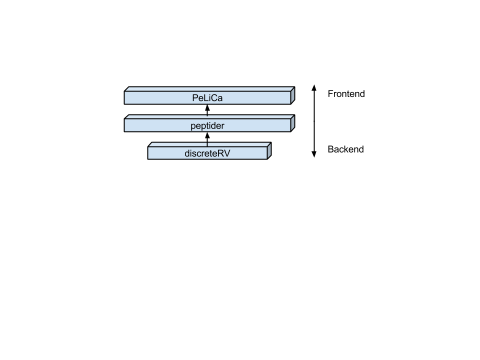

### Thank You

A special thanks to:

- Dr. Hofmann - Guiding me through this project every step of the way
- Dr. Sieber - Peptides paper, PeLiCa suggestions, biological background
- Dr. Buja - discreteRV

Any questions?